# EDA ▶ Numerical Data Distribution Shape

February 26, 2024 @ 07:28 PM

## Before We Begin…

These slides are not meant to be standalone information. You should take notes to flesh out the contents. I recommend that you create an R Markdown document where you can combine information and code from the slides and your own additional notes and explorations to make connections.

**Related Materials**

- Ch 2 of *Mathematical Statistics with Resampling and R, 2<sup>nd</sup> Ed.*
- Ch 2 of [*Modern Dive*](https://moderndive.com/2-viz.html)
- Ch 3 of [*Modern Dive*](https://moderndive.com/3-wrangling.html)
- Ch 4 of [*Modern Dive*](https://moderndive.com/4-tidy.html)
- DataCamp [Introduction to the Tidyverse](https://www.datacamp.com/courses/introduction-to-the-tidyverse)

John Tukey (1915–2000), noted mathematician, statistician, and computer scientist, author of *Exploratory Data Analysis* (1977)

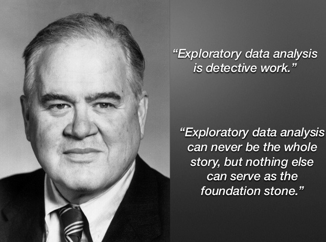

Tukey also advocated for development of computerized tools to facilitate EDA, so people could focus on *interpreting results*.

## How We Describe Distributions

**Categorical Variables**

- frequency / relative frequency

*Summaries based on counting how many times categories occur.*

**Quantitative Variables**

- shape
- center
- spread
- outliers

*Shape, center, and spread characterize the pattern of numerical observations. Outliers are deviations from the pattern.*

## Shape

- Visual assessment: how many peaks does it have?
  - unimodal, bimodal, or multimodal
- Visual assessment: is it approximately symmetric?
  - symmetric, right skewed, or left skewed
- Skewness statistic
  - numerical quantification of the degree of asymmetry
- Kurtosis statistic
  - numerical quantification of peak and tails conformation

We rely heavily on plots to assess the shape of a distribution. A determination of skewness can be difficult with a small sample or more than one mode. Summary measures like skewness and kurtosis should be interpreted *along with plots*.

## Plots for Assessing Shape

- histogram and frequency polygon
  - [`geom_histogram()`](https://ggplot2.tidyverse.org/reference/geom_histogram.html)
- density plot
  - [`geom_density()`](https://ggplot2.tidyverse.org/reference/geom_density.html)
- empirical cumulative distribution plot
  - [`stat_ecdf()`](https://ggplot2.tidyverse.org/reference/stat_ecdf.html)
- boxplot (discussed on other slides)
  - [`geom_boxplot()`](https://ggplot2.tidyverse.org/reference/geom_boxplot.html)
- normal quantile-quantile plot (discussed in other slides)
  - [`geom_qq()`](https://ggplot2.tidyverse.org/reference/geom_qq.html)

You can preview syntax and plotting options at the links above.

## What is a Histogram?

A *histogram* is a type of bar plot for displaying the distribution of a numerical variable.

- The number line in the data’s range is divided into intervals known as “bins”
- These bins are of equal width and continuous (i.e., no gaps between them)
- The frequency for each bin is the number (count) of data points that fall into that bin
- Every data point must be included in exactly one bin, with no data points left out

There are many possible ways to create a histogram for a given dataset, depending on our choice of bins. Usually we have to try more than one possibility.

## What is a Density Plot?

A *frequency polygon* connects the midpoints of histogram bins to display a very rough estimate of a continuous distribution.

A *density plot* is a variation on a histogram that uses a statistical technique called *kernel smoothing* to plot a smoothed estimate of a variable’s distribution over some continuous interval of the number line. It “averages” multiple bars, roughly speaking.

Density plots are often better at displaying the shape of a true continuous distribution than a histogram because they’re not affected by the number of bins we choose the way histograms can be. However, differences in the algorithm (e.g., “bandwidth” used) can over- or under-smooth the distribution.

The specifics of kernel smoothing are beyond the scope of this class. We will use the default settings in `R` and ggplot2.

## Some Data to Explore

Read gasmileage.csv, oldfaithful.csv, and Bangladesh.csv into RStudio. Remember you need `library(tidyverse)` for many of the functions we will use, including `read_csv()`. In coming slides the datasets will be referred to by the following names.

- `mileage`: results of 100 EPA gas mileage tests for a particular model of car, in miles per gallon (mpg)
- `geyser`: eruption data for Old Faithful geyser in Yellowstone National Park, including duration in minutes and number of minutes until the next eruption.
- `wells`: concentration of three contaminants for a sample of wells in Bangladesh, in ppb or ppm

```r
glimpse(geyser)
```

```
Rows: 272
Columns: 2
$ erupt_time <dbl> 3.600, 1.800, 3.333, 2.283, 4.533, 2.883, 4.700, 3.600, 1.9…
$ wait_time  <dbl> 79, 54, 74, 62, 85, 55, 88, 85, 51, 85, 54, 84, 78, 47, 83,…
```

```r
glimpse(wells)
```

```
Rows: 271
Columns: 3
$ Arsenic  <dbl> 2400, 6, 904, 321, 1280, 151, 141, 1050, 511, 688, 81, 8, 37,…
$ Chlorine <dbl> 6.2, 116.0, 14.8, 35.9, 18.9, 7.8, 56.3, 16.0, 40.4, 29.3, 31…
$ Cobalt   <dbl> 0.42, 0.45, 0.63, 0.68, 0.58, 0.35, 0.46, 0.59, 0.48, 0.87, 0…
```

You should also `glimpse()` the `mileage` dataset, which has only one variable: `mpg`.

## Basic Histogram for `mpg`

How many modes? Is the distribution symmetric or skewed?

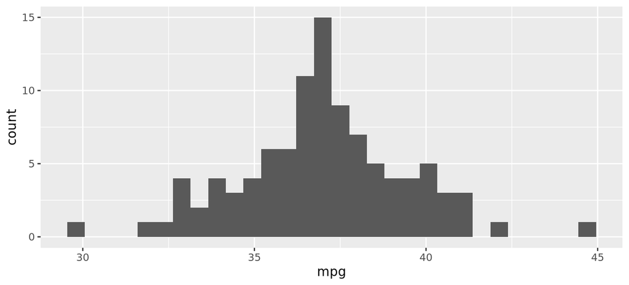

```r
ggplot(mileage, aes(x = mpg)) +
  geom_histogram() # default bins = 30
```

## Basic Frequency Polygon for `mpg`

How many modes? Is the distribution symmetric or skewed?

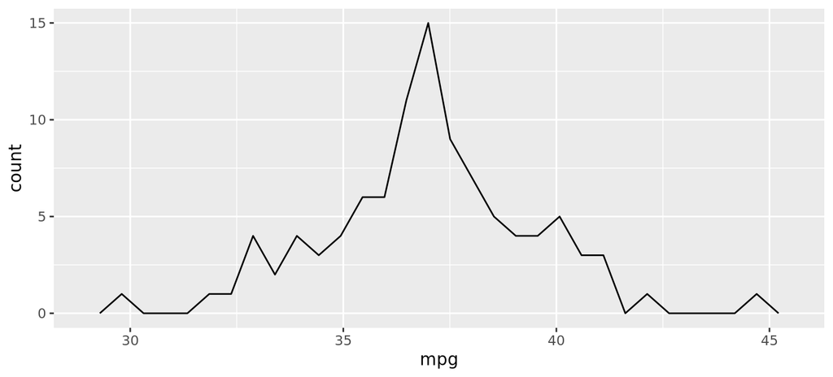

```r
ggplot(mileage, aes(x = mpg)) +
  geom_freqpoly() # default bins = 30
```

## Polygon Over Histogram for `mpg`

Notice how the two plots correspond with one another. We can plot multiple geometries for a single variable (aesthetic).

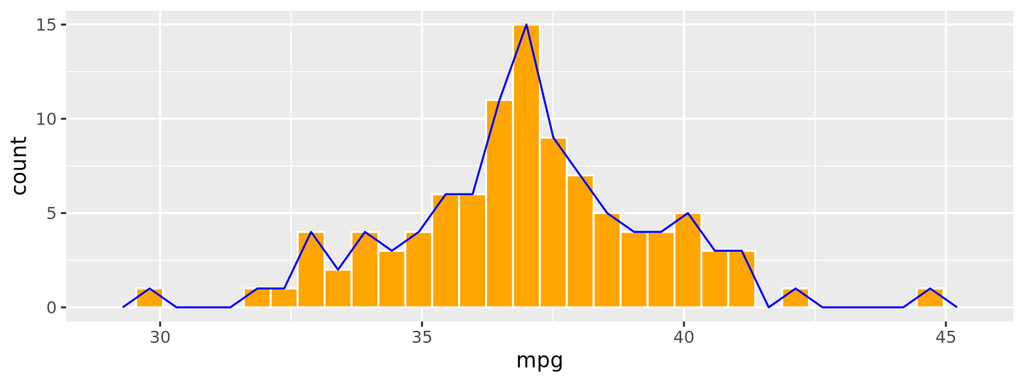

```r
ggplot(mileage, aes(x = mpg)) +
  geom_histogram(fill = "orange", color = "white") +
  geom_freqpoly(color = "blue")
```

## Basic Histogram for `erupt_time`

How many modes? Is the distribution symmetric or skewed?

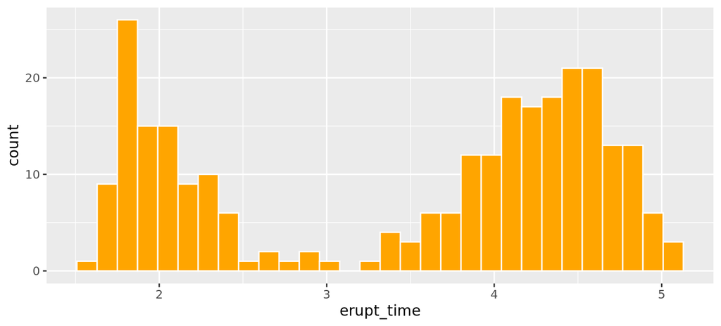

```r
ggplot(geyser, aes(x = erupt_time)) +
  geom_histogram(fill = "orange", color = "white")
```

## One Variable, Two Groups?

How many modes? Is each distribution symmetric or skewed?

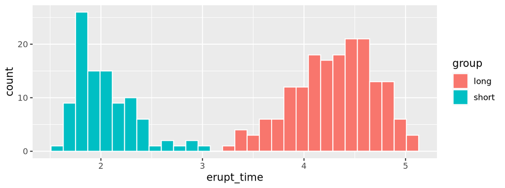

```r
geyser <- geyser %>%
  mutate(group = ifelse(erupt_time < 3.1, "short", "long"))
ggplot(geyser, aes(x = erupt_time, fill = group)) +
  geom_histogram(color = "white")
```

## Finite Lower Bound, Infinite Upper?

How many modes? Is the distribution symmetric or skewed?

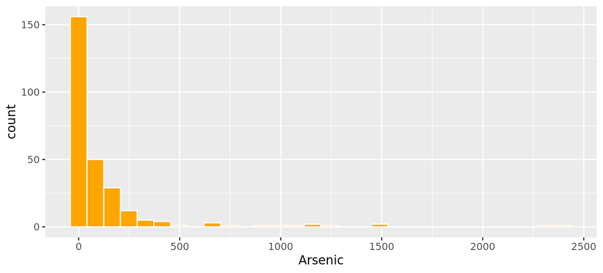

```r
ggplot(wells, aes(x = Arsenic)) +
  geom_histogram(fill = "orange", color = "white")
```

## Rules of Thumb for Number of Bins

- some sources say between 5 and 15 bins
- other sources say between 5 and 20 bins
- Freedman-Diaconis rule, about \(2 \times IQR × n^{−1/3}\) bins
- Sturge’s rule, number of bins around \(1 + 3.322 \times log(n)\)
- **a good rule is to start with a number of bins near** \(\sqrt{n}\)

Recall, \(n\) is the number of data points in the plotted sample.

Finding an appropriate number of bins is an interative process. In `R` you can set an (approximate) number of bins, *or* choose a specific bin width, *or* specify the exact boundaries you want for the bins. Overall, we want to strike a balance between detail and “smoothness”.

## Mileage Revisited #1

Mileage with \(\sqrt{n}\) bins. Approximately how wide is each bin?

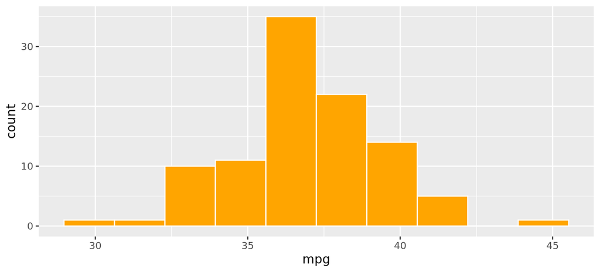

```r
ggplot(mileage, aes(x = mpg)) +
  geom_histogram(bins = 10,  fill = "orange", color = "white")
```

## Mileage Revisited #2

Mileage with 15 bins. Approximately how wide is each bin?

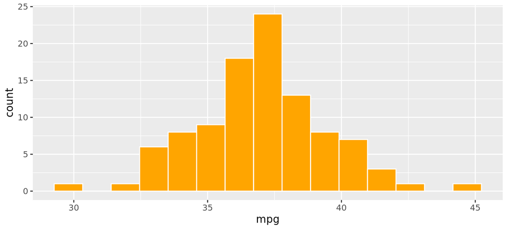

```r
ggplot(mileage, aes(x = mpg)) +
  geom_histogram(bins = 15,  fill = "orange", color = "white")
```

## Mileage Revisited #3

Mileage with bins 1 units wide. How many bins are there?

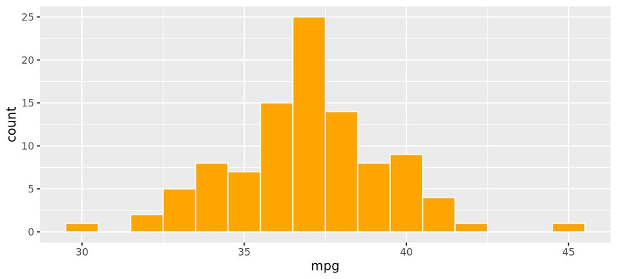

```r
ggplot(mileage, aes(x = mpg)) +
  geom_histogram(binwidth = 1, fill = "orange", color = "white")
```

## Basic Density Plot

For a continuous variable, we can estimate a smooth function.

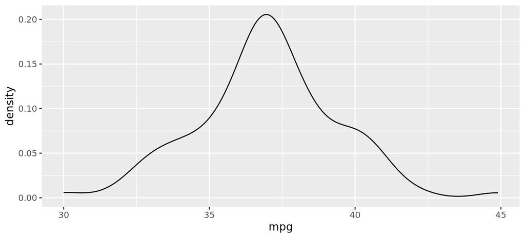

```r
ggplot(mileage, aes(x = mpg)) +
  geom_density()
```

## *Probability* Density Function (pdf)

Area under an estimated density curve is 1. Notice the y axis.

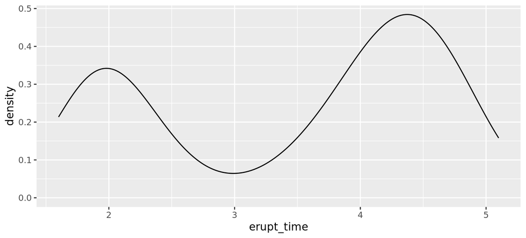

```r
ggplot(geyser, aes(x = erupt_time)) +
  geom_density()
```

## Another Density Plot

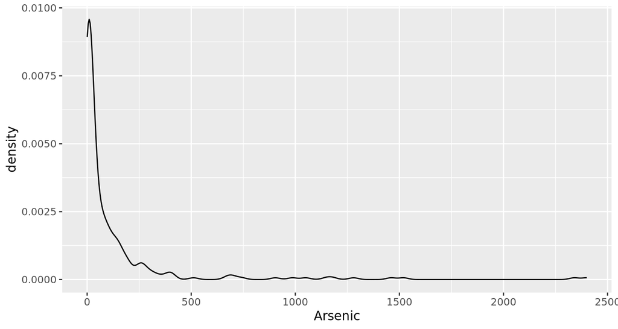

```r
ggplot(wells, aes(x = Arsenic)) +
  geom_density()
```

## Density Over Histogram

We have a smooth estimation based on the discrete data.

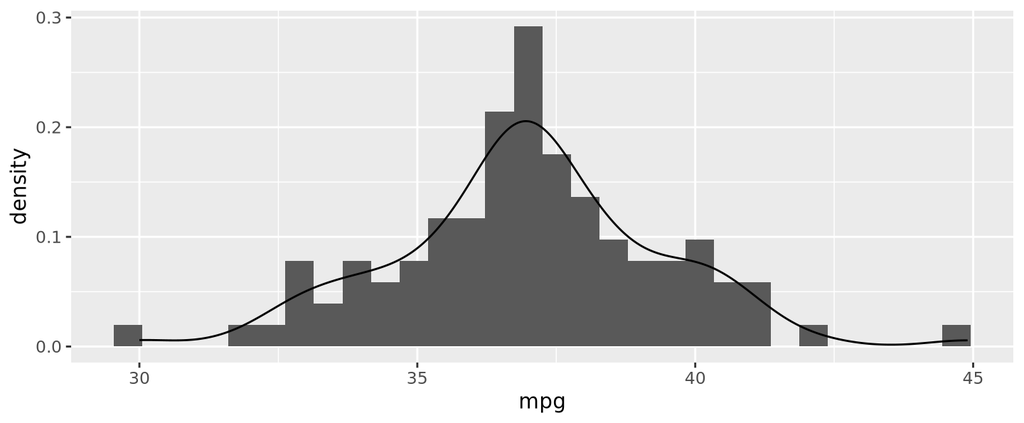

```r
ggplot(mileage, aes(x = mpg)) +
  geom_histogram(aes(y = ..density..)) + # rescales the y-axis
  geom_density()
```

## Density Over Histogram

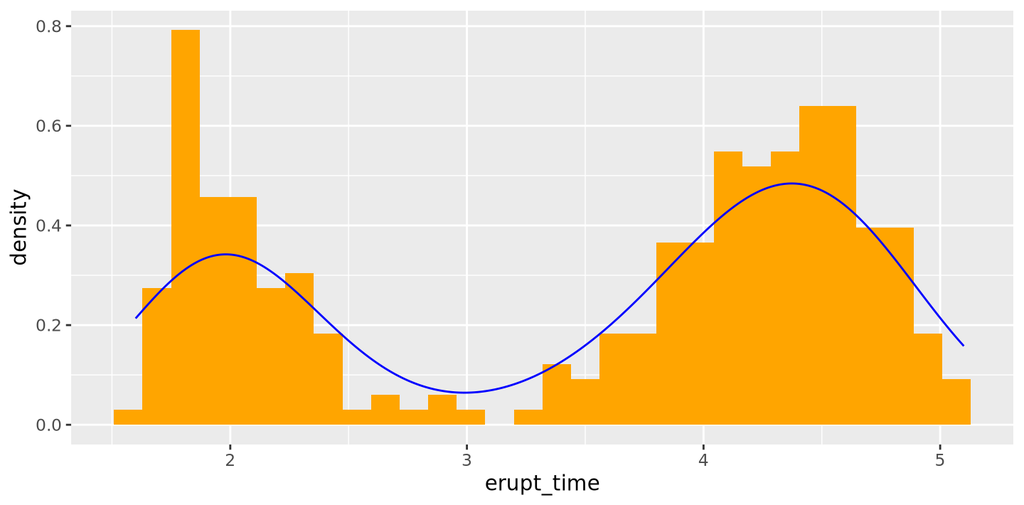

```r
ggplot(geyser, aes(x = erupt_time)) +
  geom_histogram(aes(y = ..density..), fill = "orange") +
  geom_density(color = "blue")
```

## Density Over Histogram

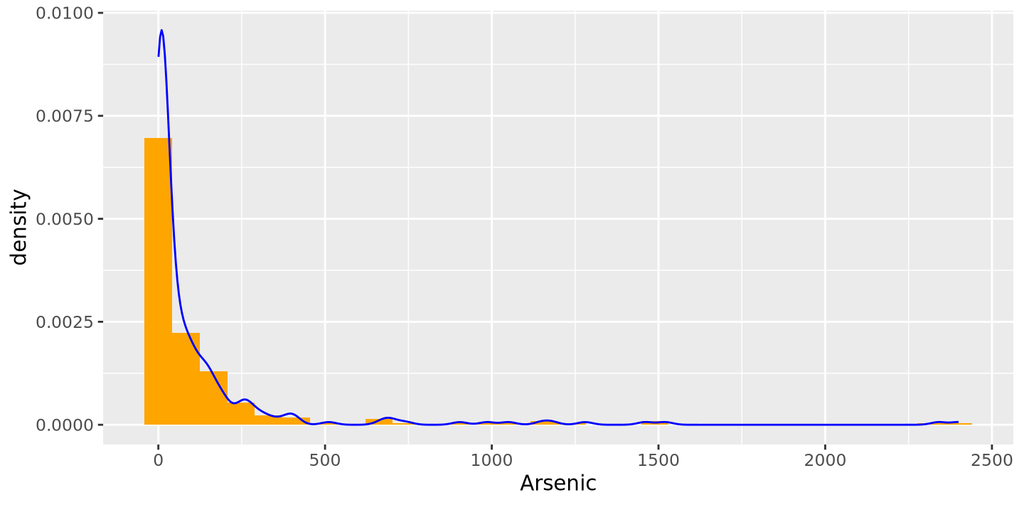

```r
ggplot(wells, aes(x = Arsenic)) +
  geom_histogram(aes(y = ..density..), fill = "orange") +
  geom_density(color = "blue")
```

## Refine the Presentation

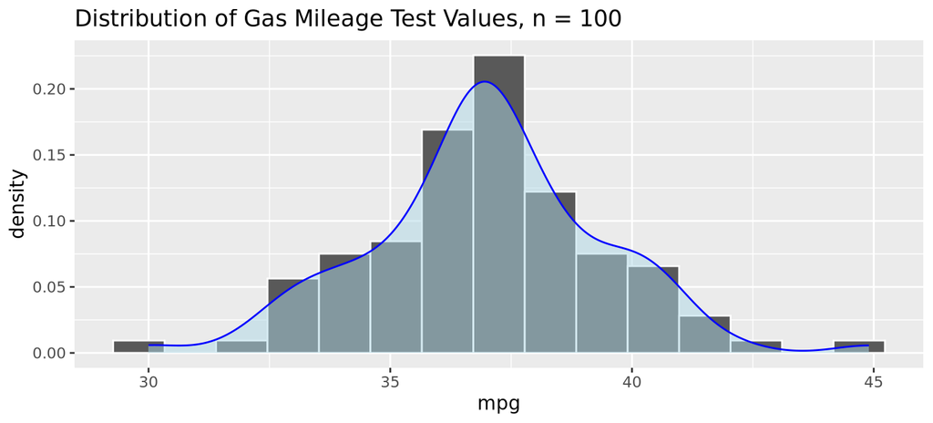

```r
ggplot(mileage, aes(x = mpg)) +
  geom_histogram(aes(y = ..density..), bins = 15, color = "white") +
  geom_density(fill = "lightblue", color = "blue", alpha = 0.50) +
  labs(title = "Distribution of Gas Mileage Test Values, n = 100")
```

## Empirical Cumulative Distribution

The integral of a density function is the cumulative distribution. Here we estimate it discretely using a step function.

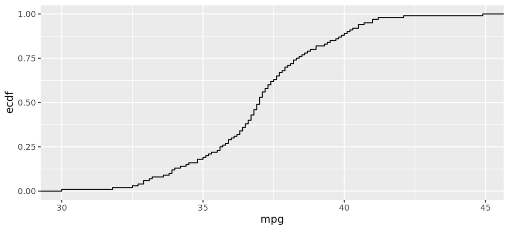

```r
ggplot(mileage, aes(x = mpg)) + stat_ecdf()
```

## Density and ECDF

The vertical line shows the 50th percentile—the halfway point.

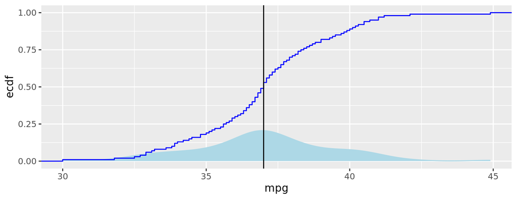

```r
ggplot(mileage, aes(x = mpg)) +
  geom_density(color = "lightblue", fill = "lightblue") +
  stat_ecdf(color = "blue") +
  geom_vline(xintercept = quantile(mileage$mpg, .5)) # median
```

## More About Plots and Shape

You will learn more about assessing distribution shape in later slides, including quantitative measures skewness and kurtosis, boxplots, and quantile-quantile plots.

Many modeling and statistical inference procedures have as an assumption that one or more variables is *approximately normal* in distribution. Determining whether this assumption is valid in a specific analysis is often necessary.

We can add labels and other customizations to these plots the same way we did when making barplots.

Practice your plotting skills on other datasets! For example, try the datasets found in Chapter 1 of MSRR, or the other variables in the datasets we explored here. What shapes do you see in the different kinds of plots? How do they connect?

## Multiple Plots with `grid.arrange()`

The `grid.arrange()` function allows us to group multiple plots into a useful or pleasing display of our choice. For several more options, refer to http://www.sthda.com/english/wiki/wiki.php?id_contents=7930.

We need the following libraries.

```r
library("gridExtra") # to organize the plots
library(grid)        # to have one top title
```

The create multiple plots and save them as objects (see next slide). Then we can arrange them in various ways.

## Create Five Plot Objects

```r
plotA <- ggplot(mileage, aes(x = mpg)) +
  geom_histogram(bins = 15)

plotB <- ggplot(mileage, aes(x = mpg)) +
  geom_density()

plotC <- ggplot(mileage, aes(x = mpg)) +
  geom_boxplot() +
  labs(y = "")# helps with spacing here

plotD <- ggplot(mileage, aes(x = mpg)) +
  stat_ecdf()

plotE <- ggplot(mileage, aes(y = mpg)) +
  geom_boxplot()
```

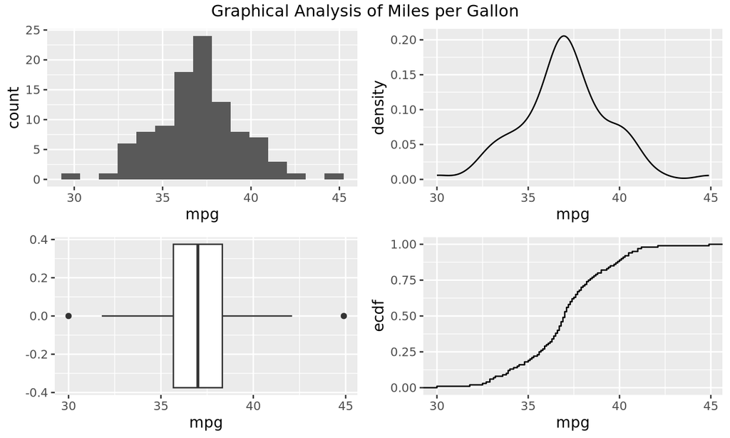

```r
grid.arrange(plotA, plotB, plotC, plotD, nrow = 2, ncol = 2,
             top = textGrob("Graphical Analysis of Miles per Gallon"))
```

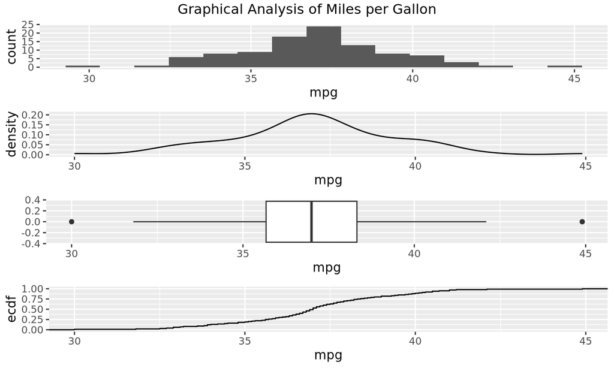

```r
grid.arrange(plotA, plotB, plotC, plotD, nrow = 4,
             top = textGrob("Graphical Analysis of Miles per Gallon"))
```

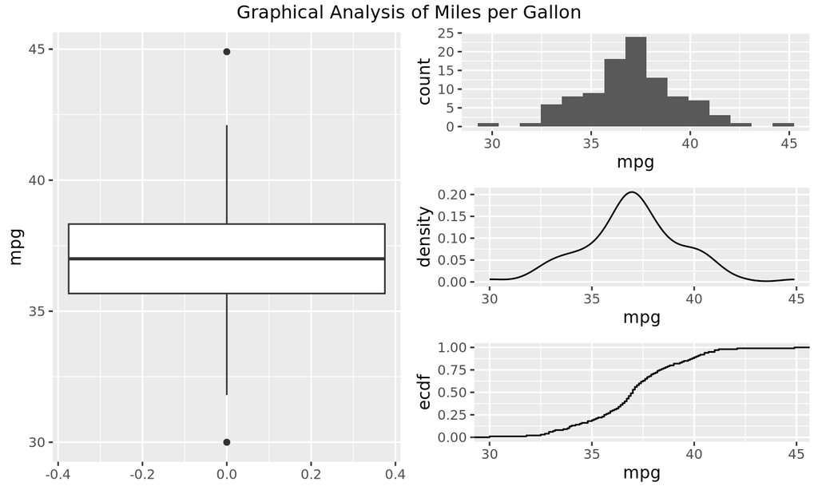

```r
grid.arrange(plotE, arrangeGrob(plotA, plotB, plotD), ncol = 2,
             top = textGrob("Graphical Analysis of Miles per Gallon"))
```